# SGD text classification

Chenlai Shi

2016-12-23

This project is aimed at developing a well-tuned, robust, scalable and accurate recommender system. Text classification and analysis is a major application field for machine learning algorithms, especially in extraction of binary information, i.e., positive or negative attitude towards the new tax plan from president, thumb up or down against a recently released movie, or even to recommend or not to recommend a freshly brewed beer. Such information that reflects the critiques is always hidden behind lines and lines of texts, which need to be decoded and classified so that large amount of text data could be further processed by the computer, so that people could utilize machine learning algorithms to reveal and extract the intrinsic statistics of text.

Based on “Large Movie Review Dataset”, containing 50,000 reviews, I have evaluated the selection of hyperparameters in Neural Networks using Stochastic Gradient Descent.

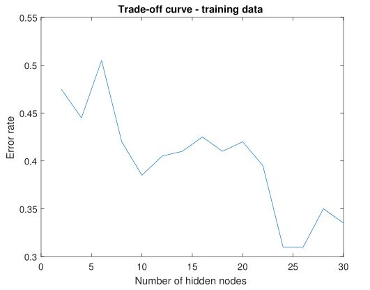

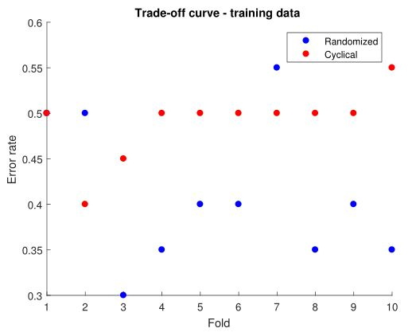

The second plot is a scatter plot of error rate for each fold. On average randomized SGD performs better than cyclic. Preliminary stage of model tuning provides clear guidelines and benchmark for further improvement over model efficiency in the future.

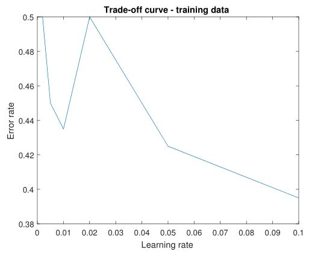

In tuning learning rate, I fixed number of hidden nodes at 25 and applied randomized SGD. From Plot 3, it can be observed a rough decline of error rate on the range of 0 to 0.1. Intuitive drawback of too small learning rate is the model converges more slowly and thus results in higher error rate. On the other hand, learning rate cannot be too large either, which will make our model too volatile.